# GEOG458_GroupLab1

Group6

1/16/2019

## Section 1, Question 1

Beijing and Shanghai are considered as “Direct Controlled Municipality”, which means they are not a province, and are directly controlled or managed by the chinese central government. Hong Kong, Macao, and Taiwan are missing from the dataset. This is because the Chinese centrol government allowed them to have their own government. However, their own government will be managed by the Chinese centrol government. Using Hong Kong as an example, Hong Kong has it own government called Hong Kong SAR Government, and the adminitrive head is called cheif executive. The chief executive will be selected by the Hong Kong residences. After the candidate is finalized, the Chinese government will review his qualifications. Once approved, he/she will be the formal cheif executive of Hong Kong. Some people may argue whether Taiwan is still part of China. The answer is yes, but so far the Taiwan government doesn’t recognize the Chinese Communism Party as the leader of their government. The [1992 Consensus](https://en.wikipedia.org/wiki/1992_Consensus) can be the support of this claim.

## Section 1, Question 2

China’s economic growth has always been questioned by others because from a third-party perspective, we are unsure of how China was able to recover. China has really impressive statistics when it comes to their GDP. In 2017, they had a 6.9% growth and also had about 30% of global economic growth. The Chinese government claim that they have entered into a new economic phase that is more domestic-centered and responsive to popular goods. But according to [Economic Front](https://economicfront.wordpress.com/2018/06/05/the-chinese-economy-problems-and-prospects/), there is a graph that shows China’s growth rate between 2011 to 2016 actually dropped significantly before the growth in 2017. There were cases that GPD data was manipulated to attempt to meet standards, such as Inner Mongolia admitted to falsifying data back in 2016.

In [China’s Economic Data: An Accurate Refelction, or Just Smoke and Mirrors](https://www.stlouisfed.org/publications/regional-economist/second-quarter-2017/chinas-economic-data-an-accurate-reflection-or-just-smoke-and-mirrors), they have a few suggestions to help collect *better* GPD. They have three mothods that we can consder; energy consumption, indexed GDP proxies, and luminosity. Because China does consume a lot of energy, changes in this particular area could help collect data. We can think of it as China consumes energy to make products which can be recording as production. A second method, indexed GDP proxies. Indexing will measure from quarter-to-quarter but with consistency it can show quarterly growth to yearly growth. The last method is luminsoity and that means to use satellite data that will measure the intensity of man-made night lights. This method is can avoid falsification and misreporting because this method would be able to track consumption of all goods that requires light.

## Section 2

## Section 2, Question 1

[figure not shown]

```r
library(plyr)
library(dplyr)
library(tidyverse)
library(ggplot2)
library(reshape2)
object1 = read.csv("China_EO_49to17.csv" ,fileEncoding="latin1")
object2 = as.tibble(object1)
datC=object2
datC$Year=seq(from=1949, to=2017)
datC=datC[order(datC$Year),]
outp = cbind(datC[,1],datC[,grep("Output", names(datC))])
enterp = cbind(datC[,1],datC[,grep("Enterprise", names(datC))])
outp_P = nrow(outp)-1
colnames(outp) <- strsplit((colnames(outp)),"_Output")
colnames(enterp) <- strsplit((colnames(enterp)),"_Enterprise")
outp_4 <- outp %>% select(Beijing,Tianjin,Chongqing,Shanghai, Year)
names(outp_4) <- c("Year","Beijing", "Tianjin", "Chongqing", "Shanghai")
meltout4 <- melt(outp_4, id.vars = "Year")
bb <- ggplot(meltout4, aes(x = Year, y = value, colour = variable)) + geom_point() + geom_smooth(method="auto", se=TRUE, fullrange=FALSE, level=0.95) + labs(title = "Fig. 1 Output of 4 Municipalities", x = "Year",y = "Output") #add regression lines and labels to a scatter plot
bb
```

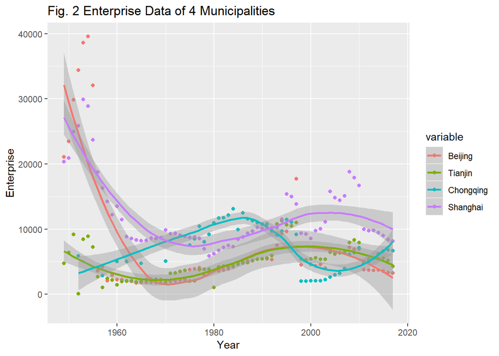

```r
#bb > the output graph

enterp4 <- enterp %>% select(Year,Beijing,Tianjin,Chongqing,Shanghai)
names(enterp4) <- c("Year","Beijing", "Tianjin", "Chongqing", "Shanghai")
meltenterp_4 <- melt(enterp4, id.vars = "Year")
bb1 <- ggplot(meltenterp_4, aes(x = Year, y = value, colour = variable)) + geom_point() + geom_smooth(method="auto", se=TRUE, fullrange=FALSE, level=0.95) + labs(title = "Fig. 2 Enterprise Data of 4 Municipalities", x = "Year",y = "Enterprise") #add regression lines and labels to a scatter plot
bb1
```

```r
#bb > the enterprise graph
```

### Output Data Narration

[output not shown]

### Enterprise Data Narration

[output not shown]

# Question 2. One of the five visualizations

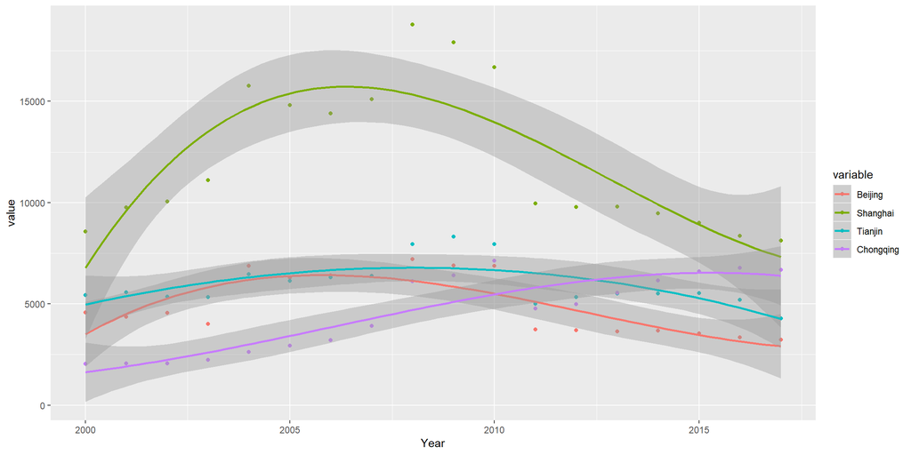

```r
library(plyr)
library(dplyr)
library(tidyverse)
library(ggplot2)
library(reshape2)

## import the csv file as tibble object
econData <- as_tibble(read.csv("China_EO_49to17.csv"))

##only interested in the enterprise data in those direct controlled cities after year 2000
DirectCity<- econData %>%
  select(Beijing_Enterprise, Shanghai_Enterprise, Tianjin_Enterprise, Chongqing_Enterprise, Year)%>%
  filter(Year >= 2000)

##rename the columns
names(DirectCity) <- c("Beijing", "Shanghai", "Tianjin", "Chongqing", "Year")

## melt the tibble object to a tall structure for plotting purpose
meltDirectCity <- melt(DirectCity, id.vars = "Year")

##plot. Different cities will have different color; applying smoothed linear regression lines with 95% confidence area
ggplot(meltDirectCity, aes(x = Year, y = value, colour = variable)) + geom_point() + scale_size_area()+ stat_smooth(method = lm, formula = y ~ splines::bs(x, 3))
```

## Second Visualization (Jody)

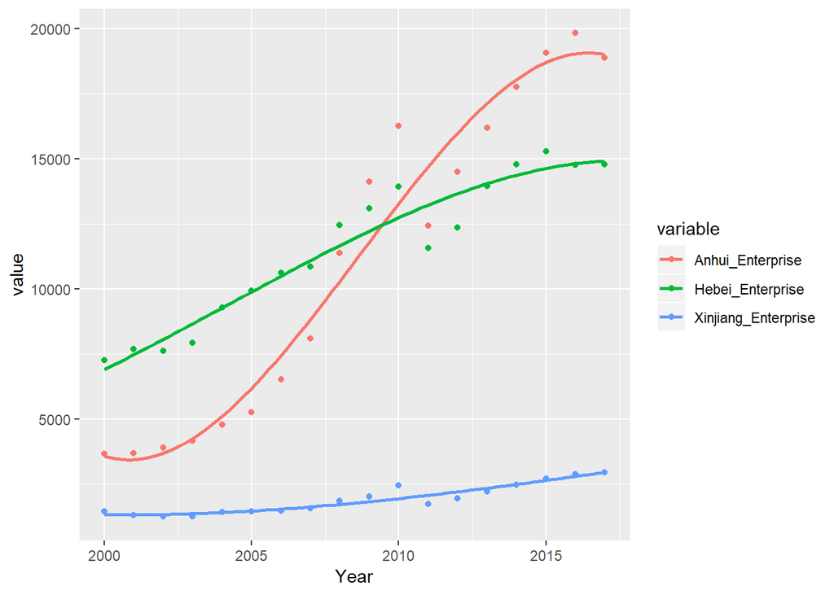

```r
## looking at enterprises of different cities.

# read the file
object1=read.csv("China_EO_49to17.csv", fileEncoding="latin1")
econData=as_tibble(object1)

# had to recreate the year column
desc <- arrange(econData, desc(Year))

# added to the table
Year=seq(from=1949, to=2017)
econData$Year=Year

# grabbed a few cities and its enterprise filters between 2000 to 2017
DataCity <- econData %>%
  select(Anhui_Enterprise, Hebei_Enterprise, Xinjiang_Enterprise, Year)%>%
  filter(Year >= 2000)

meltDataCity <- melt(DataCity, id.vars = "Year")

ggplot(meltDataCity, aes(x = Year, y = value, colour = variable)) + geom_point() + scale_size_area()+ stat_smooth(method = lm, formula = y ~ splines::bs(x, 3), se = FALSE)
```

## Third Visualization

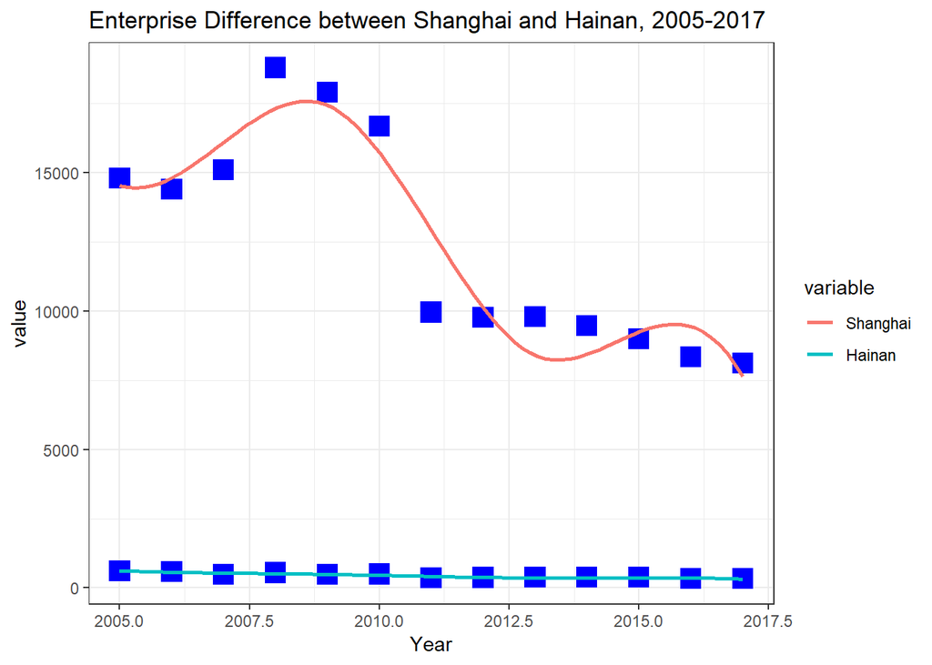

```r
library(plyr)
library(dplyr)
library(tidyverse)
library(ggplot2)
library(reshape2)

## import the csv file as tibble object
ecData <-as_tibble(read.csv("China_EO_49to17.csv"))

## enterprise data in 2 provinces after year 2005
China <- ecData %>%
  select(Shanghai_Enterprise, Hainan_Enterprise, Year)%>%
  filter(Year >= 2005)

##rename the columns
names(China) <- c("Shanghai", "Hainan", "Year")

## melt the tibble object to a tall structure for plotting purpose
Chinaa <- melt(China, id.vars = "Year")

## plot the data
ggplot(data=Chinaa,aes(x=Year,y=value,colour=variable))+geom_point(color="blue",pch=15,size=5)+ggtitle("Enterprise Difference between Shanghai and Hainan, 2005-2017")+theme_bw()+ scale_size_area()+ stat_smooth(method = lm, formula = y ~ splines::bs(x, 5), se = FALSE)
```

## Fourth Visualization

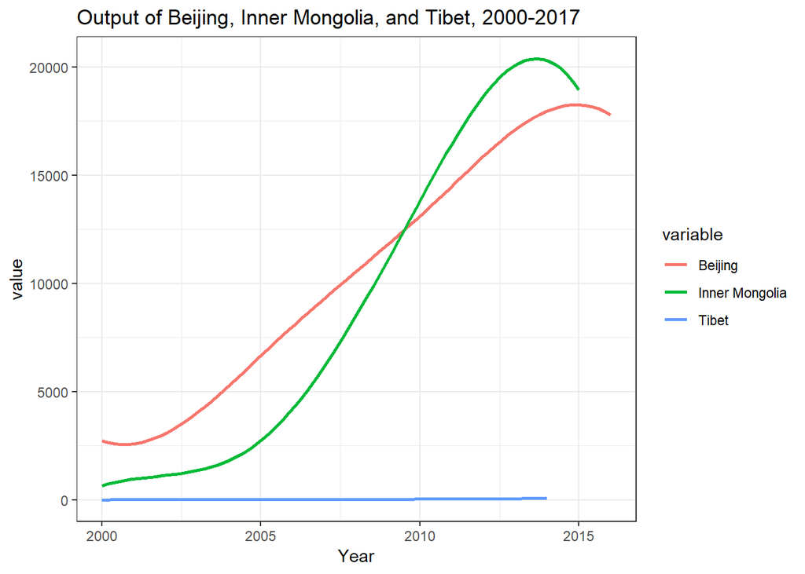

```r
library(plyr)
library(dplyr)
library(tidyverse)
library(ggplot2)
library(reshape2)

## import the csv file as tibble object
ecData <-as_tibble(read.csv("China_EO_49to17.csv"))

##only interested in the output data in certain provinces after year 2000
China <- ecData %>%
  select(Beijing_Output, InnerMongolia_Output, Tibet_Output, Year)%>%
  filter(Year >= 2000)

##rename the columns
names(China) <- c("Beijing", "Inner Mongolia", "Tibet", "Year")

## melt the tibble object to a tall structure for plotting purpose
Chinaa <- melt(China, id.vars = "Year")

## plot the data
ggplot(data=Chinaa,aes(x=Year,y=value,colour=variable))+geom_quantile()+ggtitle("Output of Beijing, Inner Mongolia, and Tibet, 2000-2017")+theme_bw()+ scale_size_area()+ stat_smooth(method = lm, formula = y ~ splines::bs(x, 5), se = FALSE)
```

## Fifth Visualization

[figure not shown]

```r
library(plyr)
library(dplyr)
library(tidyverse)
library(ggplot2)
library(reshape2)

## import the csv file as tibble object
ecData <-as_tibble(read.csv("China_EO_49to17.csv"))

## enterprise data in 1 province after year 1990 and before 2008
China <- ecData %>%
  select(Shaanxi_Enterprise, Year)%>%
  filter(Year >= 1990, Year <=2007)

##rename the columns
names(China) <- c("Shaanxi", "Year")

## melt the tibble object to a tall structure for plotting purpose
Chinaa <- melt(China, id.vars = "Year")

## plot the data
ggplot(data=Chinaa,aes(x=Year,y=value,colour=variable))+geom_area(color="red", fill="red")+ggtitle("Number of Enterprises in Shaanxi, 1990-2017")+theme_bw()+ scale_size_area()+ stat_smooth(method = lm, formula = y ~ splines::bs(x, 5), se = FALSE)
```

```r
# comparing Guangdong and Liaoning's enterprise
GuangdongLiaoning<- econData %>%
  select(Guangdong_Enterprise, Liaoning_Enterprise, Year)%>%
  filter(Year >= 2000)
names(GuangdongLiaoning) <- c("Guangdong", "Liaoning", "Year")
add_column(GuangdongLiaoning, Output_Ratio = 0)
```

```
## # A tibble: 18 x 4
##    Guangdong Liaoning  Year Output_Ratio
##        <int>    <int> <int>        <dbl>
##  1     19695     6017  2000            0
##  2     20721     5847  2001            0
##  3     22619     6017  2002            0
##  4     24494     6842  2003            0
##  5     34584    10635  2004            0
##  6     35157    11510  2005            0
##  7     37494    14754  2006            0
##  8     42260    16556  2007            0
##  9     52574    21876  2008            0
## 10     52188    23364  2009            0
## 11     53389    23832  2010            0
## 12     38305    16914  2011            0
## 13     37790    17347  2012            0
## 14     41184    17305  2013            0
## 15     41133    15707  2014            0
## 16     42113    12304  2015            0
## 17     42688     8025  2016            0
## 18     47203     6626  2017            0
```

```r
print(mutate(GuangdongLiaoning, Output_Ratio = Guangdong/Liaoning))
```

```
## # A tibble: 18 x 4
##    Guangdong Liaoning  Year Output_Ratio
##        <int>    <int> <int>        <dbl>
##  1     19695     6017  2000         3.27
##  2     20721     5847  2001         3.54
##  3     22619     6017  2002         3.76
##  4     24494     6842  2003         3.58
##  5     34584    10635  2004         3.25
##  6     35157    11510  2005         3.05
##  7     37494    14754  2006         2.54
##  8     42260    16556  2007         2.55
##  9     52574    21876  2008         2.40
## 10     52188    23364  2009         2.23
## 11     53389    23832  2010         2.24
## 12     38305    16914  2011         2.26
## 13     37790    17347  2012         2.18
## 14     41184    17305  2013         2.38
## 15     41133    15707  2014         2.62
## 16     42113    12304  2015         3.42
## 17     42688     8025  2016         5.32
## 18     47203     6626  2017         7.12
```

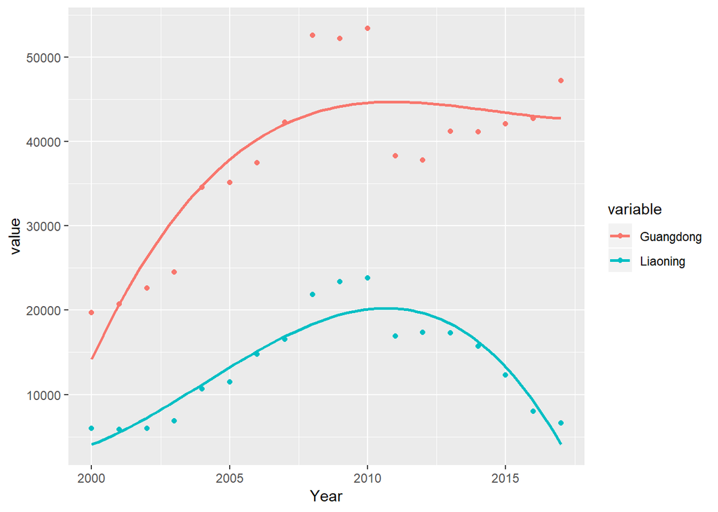

```r
meltGuangdongLiaoning <- melt(GuangdongLiaoning, id.vars = "Year")

ggplot(meltGuangdongLiaoning, aes(x = Year, y = value, colour = variable)) + geom_point() + scale_size_area()+ stat_smooth(method = lm, formula = y ~ splines::bs(x, 3), se = FALSE)
```

### Guangdong vs. Liaoning

We can see that Guangdong was able to stable themselves in the earlies 2010 wheres compared to Liaoning they have dropped.

```r
# comparing Jilin and Anhui's enterprise
JilinAnhui<- econData %>%
  select(Jilin_Enterprise, Anhui_Enterprise, Year)%>%
  filter(Year >= 2000)
names(JilinAnhui) <- c("Jilin", "Anhui", "Year")
add_column(JilinAnhui, Output_Ratio = 0)
```

```
## # A tibble: 18 x 4
##    Jilin Anhui  Year Output_Ratio
##    <int> <int> <int>        <dbl>
##  1  2728  3680  2000            0
##  2  2608  3698  2001            0
##  3  2572  3918  2002            0
##  4  2284  4158  2003            0
##  5  3280  4778  2004            0
##  6  2774  5277  2005            0
##  7  3249  6523  2006            0
##  8  3984  8111  2007            0
##  9  5257 11392  2008            0
## 10  5936 14122  2009            0
## 11  6181 16277  2010            0
## 12  5158 12432  2011            0
## 13  5286 14514  2012            0
## 14  5376 16193  2013            0
## 15  5311 17762  2014            0
## 16  5682 19077  2015            0
## 17  6003 19838  2016            0
## 18  5971 18883  2017            0
```

```r
print(mutate(JilinAnhui, Output_Ratio = Jilin/Anhui))
```

```
## # A tibble: 18 x 4
##    Jilin Anhui  Year Output_Ratio
##    <int> <int> <int>        <dbl>
##  1  2728  3680  2000        0.741
##  2  2608  3698  2001        0.705
##  3  2572  3918  2002        0.656
##  4  2284  4158  2003        0.549
##  5  3280  4778  2004        0.686
##  6  2774  5277  2005        0.526
##  7  3249  6523  2006        0.498
##  8  3984  8111  2007        0.491
##  9  5257 11392  2008        0.461
## 10  5936 14122  2009        0.420
## 11  6181 16277  2010        0.380
## 12  5158 12432  2011        0.415
## 13  5286 14514  2012        0.364
## 14  5376 16193  2013        0.332
## 15  5311 17762  2014        0.299
## 16  5682 19077  2015        0.298
## 17  6003 19838  2016        0.303
## 18  5971 18883  2017        0.316
```

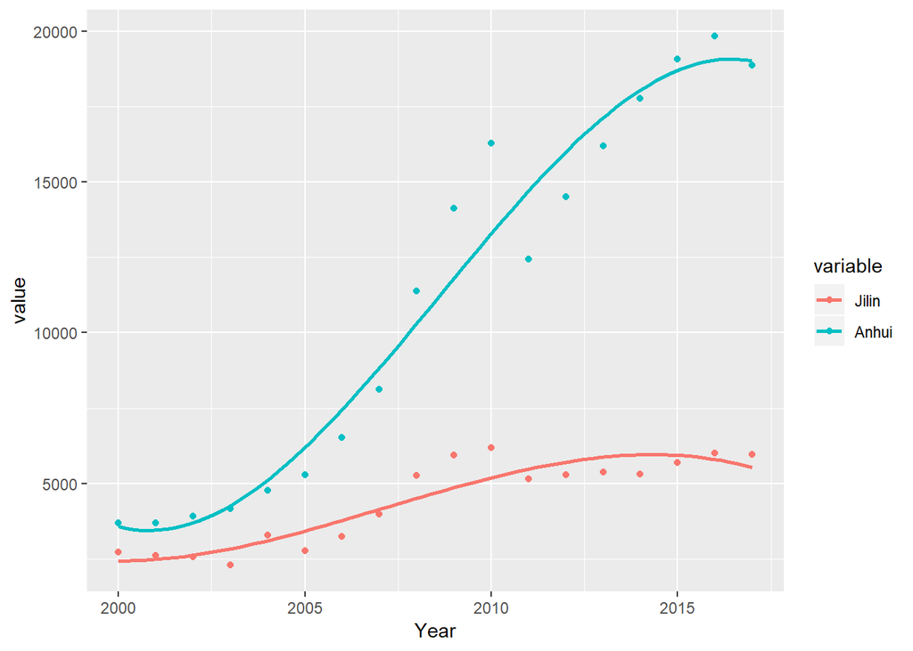

```r
meltJilinAnhui <- melt(JilinAnhui, id.vars = "Year")

ggplot(meltJilinAnhui, aes(x = Year, y = value, colour = variable)) + geom_point() + scale_size_area()+ stat_smooth(method = lm, formula = y ~ splines::bs(x, 3), se = FALSE)
```

### Jilin vs. Anhui

We can see that Anhui has grown increasingly high and Jilin has a much less smaller slope.

```r
# comparing Fujian and Guizhou's enterprise
FujianGuizhou<- econData %>%
  select(Fujian_Enterprise, Guizhou_Enterprise, Year)%>%
  filter(Year >= 2000)
names(FujianGuizhou) <- c("Fujian", "Guizhou", "Year")
add_column(FujianGuizhou, Output_Ratio = 0)
```

```
## # A tibble: 18 x 4
##    Fujian Guizhou  Year Output_Ratio
##     <int>   <int> <int>        <dbl>
##  1   6011    2087  2000            0
##  2   6583    2054  2001            0
##  3   7462    2067  2002            0
##  4   9208    2129  2003            0
##  5  11918    2545  2004            0
##  6  12396    2585  2005            0
##  7  13755    2594  2006            0
##  8  15178    2296  2007            0
##  9  17212    2676  2008            0
## 10  18154    2791  2009            0
## 11  19227    2963  2010            0
## 12  14116    2329  2011            0
## 13  15333    2752  2012            0
## 14  16120    3576  2013            0
## 15  16744    3895  2014            0
## 16  17240    4482  2015            0
## 17  17262    5123  2016            0
## 18  17348    5311  2017            0
```

```r
print(mutate(FujianGuizhou, Output_Ratio = Fujian/Guizhou))
```

```
## # A tibble: 18 x 4
##    Fujian Guizhou  Year Output_Ratio
##     <int>   <int> <int>        <dbl>
##  1   6011    2087  2000         2.88
##  2   6583    2054  2001         3.20
##  3   7462    2067  2002         3.61
##  4   9208    2129  2003         4.33
##  5  11918    2545  2004         4.68
##  6  12396    2585  2005         4.80
##  7  13755    2594  2006         5.30
##  8  15178    2296  2007         6.61
##  9  17212    2676  2008         6.43
## 10  18154    2791  2009         6.50
## 11  19227    2963  2010         6.49
## 12  14116    2329  2011         6.06
## 13  15333    2752  2012         5.57
## 14  16120    3576  2013         4.51
## 15  16744    3895  2014         4.30
## 16  17240    4482  2015         3.85
## 17  17262    5123  2016         3.37
## 18  17348    5311  2017         3.27
```

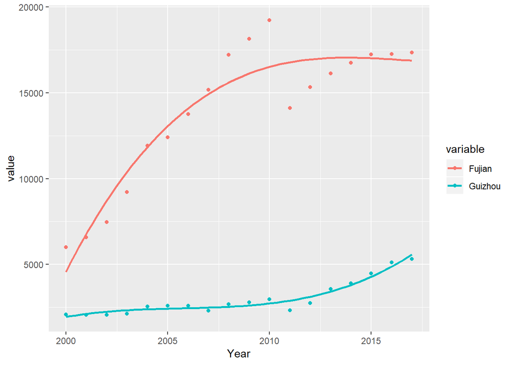

```r
meltFujianGuizhou <- melt(FujianGuizhou, id.vars = "Year")

ggplot(meltFujianGuizhou, aes(x = Year, y = value, colour = variable)) + geom_point() + scale_size_area()+ stat_smooth(method = lm, formula = y ~ splines::bs(x, 3), se = FALSE)
```

### Fujian vs. Guizhou

We can see that Fujian has a larger growth compared to Guizhou and we can say that maybe sometime in the future they would at one point have the same value.

## Section 3, question 2

Based on the plot below, provinces such as Xinjiang, Ningxia, Qinghai, Shaanxi, Tibet, Yunnan, and Guizhou have the lowest nation/province output ratio. Such provinces usually have low GDP as well, because of their weaknesses among areas like natural resources, manufacturing, and tertiary industry. Cities such as Beijing, Shanghai and Tianjing, and provinces such as Hubei, Guangdong, and Jiangsu, usually have high ratio, because of their geographical location (near ocean or river, and has plenty natural resources), and advantages in all three kinds of industries.

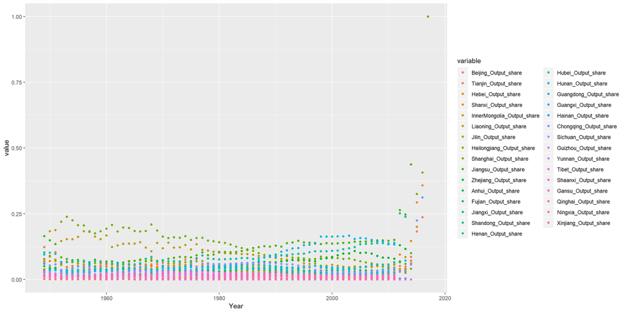

```r
##Sum national total
NationalOutput <- econData %>%
  select(matches("output"), Year) %>%
  mutate(sumVar=rowSums(.[1:19], na.rm = TRUE))

## convert to tibble object
NationalOutput <- as_tibble(NationalOutput)

##using R base functions to create new columns with the ratio between the summarized national output and each province
for(col in names(NationalOutput)) {
  NationalOutput[paste0(col, "_share")] = NationalOutput[col] / NationalOutput$sumVar
}

## subset the previous dataset for plotting purposes.
## only selecting the ratio columns which has the _share pattern
subset_NationalOutput <- select(NationalOutput, matches("share"))

## deleting useless columns, such as year ratio
subset_NationalOutput <- subset_NationalOutput[,1:31]

## adding the actual year column
subset_NationalOutput<-add_column(subset_NationalOutput, NationalOutput$Year)

## reassign the year column with a new name
colnames(subset_NationalOutput)[32]<-"Year"

##melt the tibble object to a tall structure
melt_subNational <- melt(subset_NationalOutput, id.vars = "Year")

##plot
ggplot(melt_subNational, aes(x = Year, y = value, colour = variable)) + geom_point()
```

## Section 3, Question 3

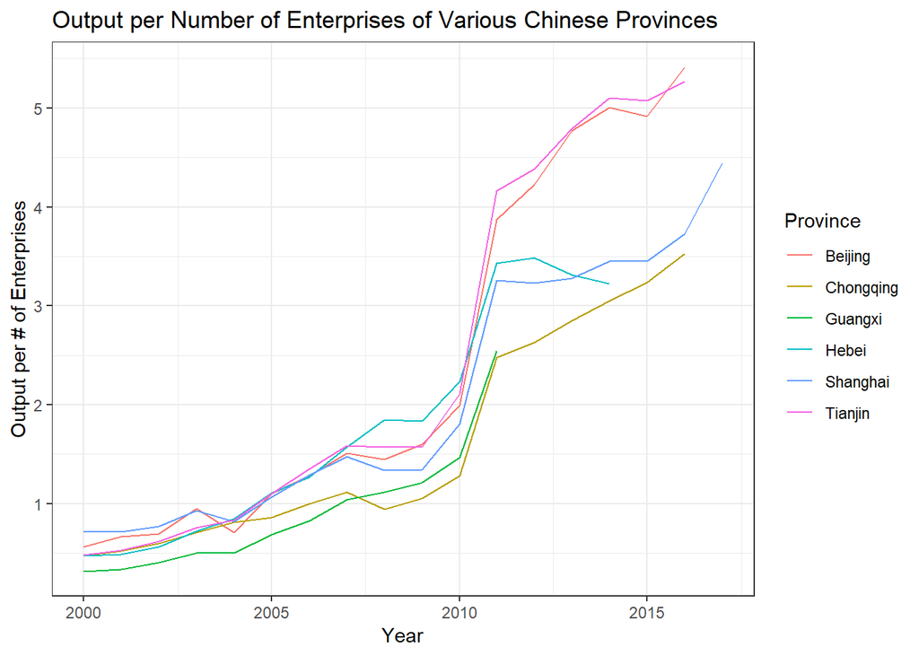

```r
econData <- as_tibble(read.csv("China_EO_49to17.csv"))

# Ratio of Output to enterprise for Beijing, Tianjin, Hebei, Shanghai
# Outputs a data frame that just contains the ratio along with their respective years
# Also a column containing their city name for ease of plotting
ratioBeijing <- econData %>%
  mutate(OutputPerEnterprise = Beijing_Output / Beijing_Enterprise) %>%
  select(Year,OutputPerEnterprise)
ratioBeijing$Province <- rep("Beijing",nrow(ratioBeijing))

ratioTianjin <- econData %>%
  mutate(OutputPerEnterprise = Tianjin_Output / Tianjin_Enterprise) %>%
  select(Year,OutputPerEnterprise)
ratioTianjin$Province <- rep("Tianjin",nrow(ratioTianjin))

ratioHebei <- econData %>%
  mutate(OutputPerEnterprise = Hebei_Output / Hebei_Enterprise) %>%
  select(Year,OutputPerEnterprise)
ratioHebei$Province <- rep("Hebei",nrow(ratioHebei))

ratioShanghai <- econData %>%
  mutate(OutputPerEnterprise = Shanghai_Output / Shanghai_Enterprise) %>%
  select(Year,OutputPerEnterprise)
ratioShanghai$Province <- rep("Shanghai",nrow(ratioShanghai))

ratioGuangxi <- econData %>%
  mutate(OutputPerEnterprise = Guangxi_Output / Guangxi_Enterprise) %>%
  select(Year,OutputPerEnterprise)
ratioGuangxi$Province <- rep("Guangxi",nrow(ratioGuangxi))

ratioChongqing <- econData %>%
  mutate(OutputPerEnterprise = Chongqing_Output / Chongqing_Enterprise) %>%
  select(Year,OutputPerEnterprise)
ratioChongqing$Province <- rep("Chongqing",nrow(ratioChongqing))

# Combines all the data frames into one for plotting
ratio <- rbind(ratioBeijing, ratioTianjin, ratioHebei, ratioShanghai, ratioGuangxi, ratioChongqing) %>%
  filter(Year >= 2000)

# Plots the data
ggplot(data=ratio,aes(x=Year,y=OutputPerEnterprise,color=Province)) +geom_line() + ylab("Output per # of Enterprises") + ggtitle("Output per Number of Enterprises of Various Chinese Provinces") +theme_bw()
```

We can see a few trends in this plot: First, a tight linear growth in which most of the provinces are just about equal and the lead spot goes from Shanghai to Hebei around 2005. Second, in 2011, there seems to have been an event that triggered a massive spurt in output per number of enterprises, leading to the dominance of Beijing and Tianjin in this plot. There is some data missing, for example Hebei from the year 2015 on, where it seemed like it was beginning to start a downward trend.

## Section 3, Question 4

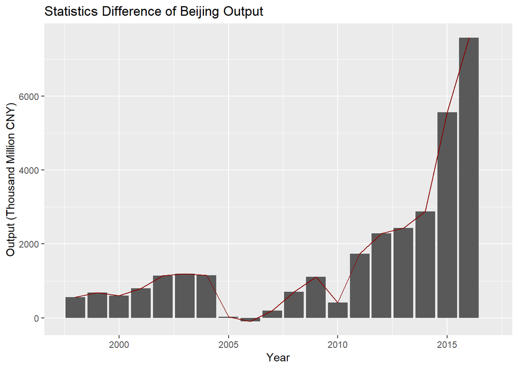

```r
library(tidyverse)
library(dplyr)
library(ggplot2)
object3 = read.csv("Municip_output.csv",stringsAsFactors = FALSE)
municp = as.tibble(object3)
munip <- municp
allc_muni <- outp[50:69,]
allc_muni <- allc_muni[,c(1:3, 23, 10) ] #extract wanted data
for (i in 1:5) {
  if(i >1){
    munip[,i]<- (municp[,i] - allc_muni[,i]) # calculate the difference
  }
}

#print four graphs of differences of the four municipalities
pB <-ggplot(munip, aes(Year, Beijing))
pB +geom_bar(stat = "identity")+geom_line(aes(x = munip$Year, y = Beijing),colour = "darkred")+
  labs(title = "Statistics Difference of Beijing Output", x = "Year",y = "Output (Thousand Million CNY)")
```

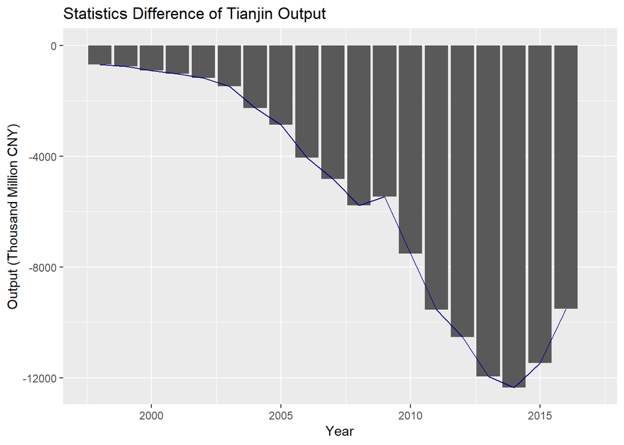

```r
#Beijing Stat Diff

pT <-ggplot(munip, aes(Year, Tianjin))
pT +geom_bar(stat = "identity")+geom_line(aes(x = munip$Year, y = Tianjin),colour = "darkblue")+
  labs(title = "Statistics Difference of Tianjin Output", x = "Year",y = "Output (Thousand Million CNY)")
```

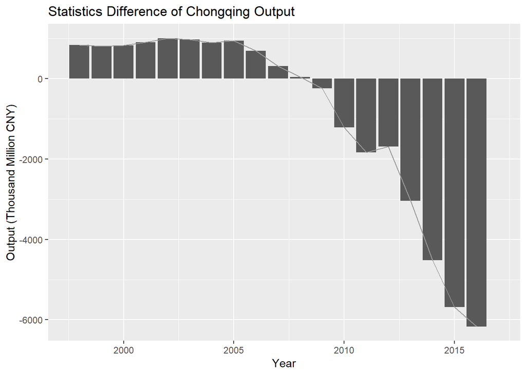

```r
#Tianjin Stat Diff

pC <-ggplot(munip, aes(Year, Chongqing))
pC +geom_bar(stat = "identity")+geom_line(aes(x = munip$Year, y = Chongqing),colour = "grey60")+
  labs(title = "Statistics Difference of Chongqing Output", x = "Year",y = "Output (Thousand Million CNY)")
```

[figure not shown]

```r
#Chongqing Stat Diff

pS <-ggplot(munip, aes(Year, Shanghai))
pT +geom_bar(stat = "identity")+geom_line(aes(x = munip$Year, y = Shanghai),colour = "lightsalmon4")+
  labs(title = "Statistics Difference of Shanghai Output", x = "Year",y = "Output (Thousand Million CNY)")
```

```r
#Shanghai Stat Diff
```

### 3.4 Graph Explanation

[output not shown]

## Section 3, Question 5

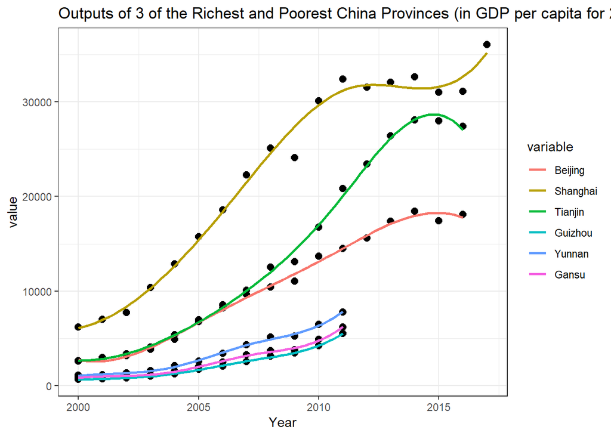

```r
library(plyr)
library(dplyr)
library(tidyverse)
library(ggplot2)
library(reshape2)

## import the csv file as tibble object
ecData <-as_tibble(read.csv("China_EO_49to17.csv"))


##only interested in the output data in those direct controlled cities after year 2000
China <- ecData %>%
  select(Beijing_Output, Shanghai_Output, Tianjin_Output, Guizhou_Output, Yunnan_Output, Gansu_Output, Year)%>%
  filter(Year >= 2000)

##rename the columns
names(China) <- c("Beijing", "Shanghai", "Tianjin", "Guizhou", "Yunnan", "Gansu", "Year")

## melt the tibble object to a tall structure for plotting purpose
Chinaa <- melt(China, id.vars = "Year")

##ploting the values
ggplot(data=Chinaa,aes(x=Year,y=value,colour=variable))+geom_point(color="black",pch=20,size=4)+ggtitle("Outputs of 3 of the Richest and Poorest China Provinces (in GDP per capita for 2017) from 2000-2017")+theme_bw()+ scale_size_area()+ stat_smooth(method = lm, formula = y ~ splines::bs(x, 5), se = FALSE)
```

###Explanation of the plot This plot shows that while the richest and poorest provinces outputs (based on 2017 data for GDP per capita) in China have been increased over the years, the outputs between provinces has widen considerably. Thus the data suggests that there is a widening gap in wealth between richest and poorest provinces. However, this assertion should be taken with a grain of salt (in consideration of how wide the gap is) as China provinces have been historically inflating their reported figures over the years. Still, there seems to be a trend that China has growing gap in outputs between different provinces, thus suggesting a correlation with the wealth gap as well (which is one of key issues in China).

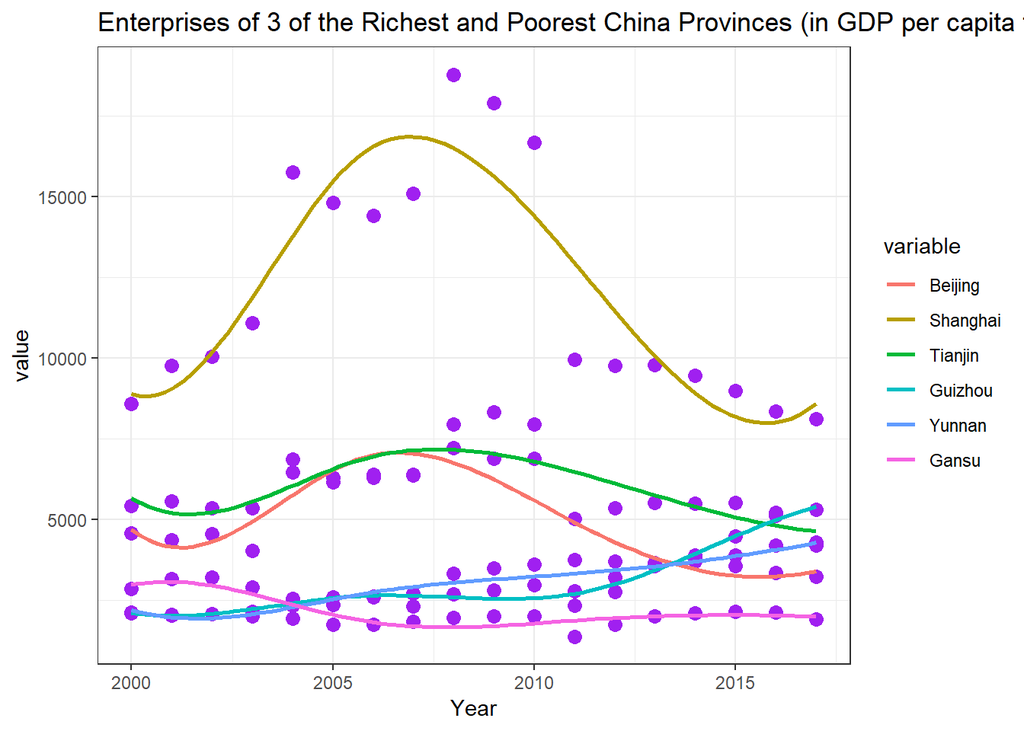

```r
library(plyr)
library(dplyr)
library(tidyverse)
library(ggplot2)
library(reshape2)

## import the csv file as tibble object
ecData <-as_tibble(read.csv("China_EO_49to17.csv"))

##only interested in the enterprise data in those direct controlled cities after year 2000
China <- ecData %>%
  select(Beijing_Enterprise, Shanghai_Enterprise, Tianjin_Enterprise, Guizhou_Enterprise, Yunnan_Enterprise, Gansu_Enterprise, Year)%>%
  filter(Year >= 2000)

##rename the columns
names(China) <- c("Beijing", "Shanghai", "Tianjin", "Guizhou", "Yunnan", "Gansu", "Year")


## melt the tibble object to a tall structure for plotting purpose
Chinaa <- melt(China, id.vars = "Year")

##ploting the values
ggplot(data=Chinaa,aes(x=Year,y=value,colour=variable))+geom_point(color="purple",pch=19,size=3)+ggtitle("Enterprises of 3 of the Richest and Poorest China Provinces (in GDP per capita for 2017) from 2000-2017")+theme_bw()+ scale_size_area()+ stat_smooth(method = lm, formula = y ~ splines::bs(x, 5), se = FALSE)
```

###Explanation of the plot On the other hand, the number of enterprises have little gap between the provinces (regardless of their wealth gap), excluding Shanghai. The small differences between these provinces may have to do with the number of state-owned enterprises (a legal entity that takes in commerical activity on behalf of the government), which could mean that they are not as affected by the wealth of the surrounding provinces in terms of location. Shanghai may be an exception here because it is much wealthier, thus could attract more enterprises to the area. However, this is simply a guess as other variables, such as population, can affect the number of enterprises.

## Section 3, Question 6

```r
## Add the China_EO_49t017 csv
data1 <- read.csv("China_EO_49to17.csv")

##only select columns contains "output"
data1_output<- select(data1, matches("output"), Year)

##only select columns contains "enterprise"
data1_enterprise <-select(data1, matches("enterprise"), Year)

##for output columns, depend on the provinces in each region, add them together. Do this for 8 regions
##for enterprise columns, depend on the provinces in each region, add them together. Do this for 8 regions

##Northeast region, Output
NE_Output_Sum <- data1_output %>%
  select("Liaoning_Output", "Jilin_Output", "Heilongjiang_Output", Year) %>%
  mutate(Northeast_Output =rowSums(.[1:3], na.rm = TRUE))

##Northeast region, enterprise
NE_Enterprise_Sum <- data1_enterprise %>%
  select("Liaoning_Enterprise", "Jilin_Enterprise", "Heilongjiang_Enterprise", Year) %>%
  mutate(Northeast_Enterprise =rowSums(.[1:3], na.rm = TRUE))

##North coastal region, Output
NC_Output_Sum <- data1_output %>%
  select("Beijing_Output", "Tianjin_Output", "Hebei_Output", "Shandong_Output", Year) %>%
  mutate(NorthcCostal_Output =rowSums(.[1:3], na.rm = TRUE))

##north coastal region, enterprise
NC_Enterprise_Sum <- data1_enterprise %>%
  select("Beijing_Enterprise", "Tianjin_Enterprise", "Hebei_Enterprise", "Shandong_Enterprise", Year) %>%
  mutate(NorthCoastal_Enterprise =rowSums(.[1:3], na.rm = TRUE))

##East coastal region, Output
EC_Output_Sum <- data1_output %>%
  select("Shanghai_Output", "Jiangsu_Output", "Zhejiang_Output", Year) %>%
  mutate(EastCostal_Output =rowSums(.[1:3], na.rm = TRUE))

##East coastal region, enterprise
EC_Enterprise_Sum <- data1_enterprise %>%
  select("Shanghai_Enterprise", "Jiangsu_Enterprise", "Zhejiang_Enterprise", Year) %>%
  mutate(EastCostal_Enterprise =rowSums(.[1:3], na.rm = TRUE))

##South coastal region, Output
SC_Output_Sum <- data1_output %>%
  select("Fujian_Output", "Guangdong_Output", "Hainan_Output", Year) %>%
  mutate(SouthCostal_Output =rowSums(.[1:3], na.rm = TRUE))

##South coastal region, enterprise
SC_Enterprise_Sum <- data1_enterprise %>%
  select("Fujian_Enterprise", "Guangdong_Enterprise", "Hainan_Enterprise", Year) %>%
  mutate(SouthCostal_Enterprise =rowSums(.[1:3], na.rm = TRUE))

##Yellow river region, Output
YellowRiver_Output_Sum<-data1_output %>%
  select("Shanxi_Output", "InnerMongolia_Output", "Henan_Output", "Shaanxi_Output", Year) %>%
  mutate(YellowRiver_Output =rowSums(.[1:4], na.rm = TRUE))

##Yellow river region, enterprise
YellowRiver_Enterprise_Sum <- data1_enterprise %>%
  select("Shanxi_Enterprise", "InnerMongolia_Enterprise", "Henan_Enterprise", "Shaanxi_Enterprise", Year) %>%
  mutate(YellowRiver_Enterprise =rowSums(.[1:3], na.rm = TRUE))

##Yangtz river region, output
Yangtz_Output_Sum <- data1_output %>%
  select("Anhui_Output", "Jiangxi_Output", "Hubei_Output", "Hunan_Output",Year) %>%
  mutate(Yangtz_Output =rowSums(.[1:4], na.rm = TRUE))

## Yangtz river region, enterprise
Yangtz_Enterprise_Sum <-  data1_enterprise %>%
  select("Anhui_Enterprise", "Jiangxi_Enterprise", "Hubei_Enterprise", "Hunan_Enterprises", Year) %>%
  mutate(Yangtz_Enterprise =rowSums(.[1:4], na.rm = TRUE))

## Southwest region, output
SW_Output_Sum <- data1_output %>%
  select("Guangxi_Output", "Chongqing_Output", "Sichuan_Output", "Guizhou_Output", "Yunnan_Output", Year) %>%
  mutate(Southwest_Output =rowSums(.[1:5], na.rm = TRUE))

## Southwest region, enterprise
SW_Enterprise_Sum <- data1_enterprise %>%
  select("Guangxi_Enterprise", "Chongqing_Enterprise", "Sichuan_Enterprise", "Guizhou_Enterprise", "Yunnan_Enterprise", Year) %>%
  mutate(Southwest_Enterprise =rowSums(.[1:5], na.rm = TRUE))

## Northwest region, output
NW_Output_Sum <- data1_output %>%
  select("Tibet_Output", "Gansu_Output", "Qinghai_Output", "Ningxia_Output", "Xinjiang_Output", Year) %>%
  mutate(Northwest_Output =rowSums(.[1:5], na.rm = TRUE))

## Northwest region, enterprise
NW_Enterprise_Sum <- data1_enterprise %>%
  select("Tibet_Enterprise", "Gansu_Enterprise", "Qinghai_Enterprise", "Ningxia_Enterprise", "Xinjiang_Enterprise", Year) %>%
  mutate(Northwest_Enterprise =rowSums(.[1:5], na.rm = TRUE))

## Join all regional output columns together as dataframe
Output_Region <- data.frame(EC_Output_Sum, NC_Output_Sum, NE_Output_Sum, NW_Output_Sum, SC_Output_Sum, SW_Output_Sum, Yangtz_Output_Sum, YellowRiver_Output_Sum)

##cleaning unnecessary columns contain "Year."
Output_Region <- Output_Region %>%
  select(-matches("Year."))

## Join all regional enterprise columns together as dataframe
Enterprise_Region <- data.frame(EC_Enterprise_Sum, NC_Enterprise_Sum, NE_Enterprise_Sum, NW_Enterprise_Sum, SC_Enterprise_Sum, SW_Enterprise_Sum, Yangtz_Enterprise_Sum, YellowRiver_Enterprise_Sum, na.rm = TRUE)

## cleaning unnecessary columns contain "year."
Enterprise_Region <- Enterprise_Region %>%
  select(-matches("Year."))

##############This is for the added data

##external csv from Nation Bureau of Statistics of China, contains population
##    estimates from 2000 - 2017, for all provinces in mainland China

added <- read.csv("AnnualbyProvince.csv")

## user defined function. subset the population dataset to smaller datasets by regions,
##      prov1:prove5: province name
Region_function <- function(prov1, prov2, prov3, prov4, prov5){
  subset(added, Region == prov1 | Region == prov2 | Region == prov3 | Region == prov4 | Region == prov5)
}

## user defined function. Summarize any regional population subset
Pop_sum_function <- function(dataset, region_name){
  dataset %>%
    summarize_at(vars(starts_with("x")), funs(sum(., na.rm = TRUE))) %>%
  mutate(Region = region_name)
}

## Naming convention: "region_name"_pop: the initial subset for all provinces in each region.
##          "Region_name"_pop_sum": summarize all provinces in each region by year

##For Northeast region
NE_pop <- Region_function("Liaoning", "Jilin", "Heilongjiang", NA, NA)
NE_pop_sum <- Pop_sum_function(NE_pop, "Northeast_pop")

## For North coastal region
NC_pop <- Region_function("Beijing", "Tianjin", "Hebei", "Shandong", NA)
NC_pop_sum <- Pop_sum_function(NC_pop, "NorthCoastal")

## For East coastal
EC_pop <- Region_function("Shanghai", "Jiangsu", "Zhejiang", NA, NA)
EC_pop_sum <- Pop_sum_function(EC_pop, "EastCoastal")

## For south coastal
SC_pop <- Region_function("Fujian", "Guangdong", "Hainan", NA, NA)
SC_pop_sum <- Pop_sum_function(SC_pop, "SouthCoastal")

## For Yellow River Region
YellowRiver_pop <- Region_function("Shanxi", "InnerMongolia", "Henan", "Shaanxi", NA)
YellowRiver_pop_sum <- Pop_sum_function(YellowRiver_pop, "YellowRiverRegion")

## For Yangtz River Region
Yangtz_pop <- Region_function("Anhui", "Jiangxi", "Hubei", "Hunan", NA)
Yangtz_pop_sum <- Pop_sum_function(Yangtz_pop, "YangtzRegion")

## For SouthWest Region
SW_pop <- Region_function("Guangxi", "Chongqing", "Sichuan", "Guizhou", "Yunnan")
SW_pop_sum<-Pop_sum_function(SW_pop, "Southwest")

## For Northwest region
NW_pop <- Region_function("Tibet", "Gansu", "Qinghai", "Ningxia", "Xinjiang")
NW_pop_sum<-Pop_sum_function(NW_pop, "Northwest")

## join all rows by cbind
RegionalPop<- rbind(NE_pop_sum, NC_pop_sum, EC_pop_sum, SC_pop_sum, YellowRiver_pop_sum, Yangtz_pop_sum, SW_pop_sum, NW_pop_sum)
```